# Crosswalk Demo

```r
library(tidyverse)
library(sf)
library(dataRetrieval) # WQP web service library
library(XML)
library(leaflet)
library(mapview)
knitr::opts_chunk$set(echo = TRUE, message = FALSE)
NHD_URL <- 'https://hydro.nationalmap.gov/arcgis/services/nhd/MapServer/WMSServer'
find_lake_word <- function(data, search_term, state_abbr = NULL) {
  if (!missing(state_abbr)) {
    if (!state_abbr %in% state.abb) stop("Use a valid 2-letter state abbreviation")
  }
  if (missing(state_abbr)) {
    filtered_data <- data[apply(data, 1, function(x) any(grepl(search_term, x, ignore.case = TRUE))),]
  }
  else {
    filtered_data <- data[apply(data, 1, function(x) any(grepl(search_term, x, ignore.case = TRUE))) & data$State == state.abb,]
  }
  return_data <- filtered_data %>%
    distinct(lagoslakeid) %>%
    inner_join(data, by = "lagoslakeid")
  return(return_data)

}
```

This notebook will show some examples of the complex relationships that can be found in the LAGOS Lake Link (lake identifier crosswalk) as well as examples of problems that could possibly be solved with some more work. For a more detailed introduction to LAGOS Lake Link and a description of the creation process, see the document “LAGOS Lake Link: Creation”

# Definitions in this document

“Lake”: Permanent lake or reservoir.

# What is LAGOS Lake Link?

LAGOS Lake Link is a tabular dataset (a crosswalk table) that can be used to connect one lake-related dataset to another for many common lake datasets. Several lake datasets are in common use on their own or as a base for scientific data products and LAGOS Lake Link is intended to make it easier to combine lake-related data between multiple sources. The table can be searched to find identifiers and location for a particular lake, or it can be used in data join operations to convert identifiers en masse.

# Data dictionary

```r
data_dictionary <- read_csv("LAGOS_Lake_Link_data_dictionary.csv")
knitr::kable(data_dictionary, "html")
```

[output not shown]

[output cut: 212 more lines]

[output not shown]

# Entity-relationship diagram

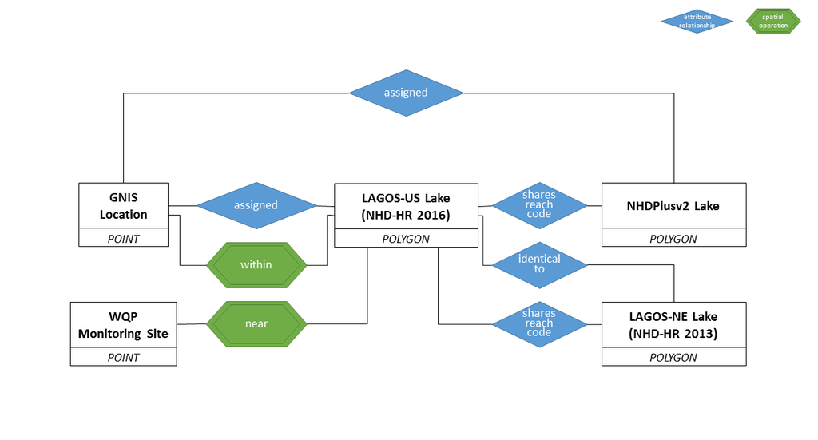

Entity-relationship diagram

Preview of the crosswalk table. As a reminder, there are **479950 LAGOS-US lakes**.

```r
glimpse(xwalk, width = 100)
```

```
Observations: 594,622
Variables: 28
$ lagoslakeid                      <int> 31198, 31198, 31198, 31198, 31198, 31198, 122, 122, 12...
$ nhdhr_permanentidentifier        <chr> "120020498", "120020498", "120020498", "120020498", "1...
$ nhdhr_reachcode                  <chr> "04010201003330", "04010201003330", "04010201003330", ...
$ nhdhr_areasqkm                   <dbl> 2.745000, 2.745000, 2.745000, 2.745000, 2.745000, 2.74...
$ nhdhr_fdate                      <dttm> 2004-03-16 18:37:00, 2004-03-16 18:37:00, 2004-03-16 ...
$ gnis_id                          <int> 649289, 649289, 649289, 649289, 649289, 649289, 653169...
$ gnis_name                        <chr> "Perch Lake", "Perch Lake", "Perch Lake", "Perch Lake"...
$ lagos_lakename                   <chr> "Perch Lake", "Perch Lake", "Perch Lake", "Perch Lake"...
$ lagos_countyname                 <chr> "Carlton County", "Carlton County", "Carlton County", ...
$ lagos_countyfips                 <int> 27017, 27017, 27017, 27017, 27017, 27017, 27017, 27017...
$ lagos_lakelatitude               <dbl> 46.68943, 46.68943, 46.68943, 46.68943, 46.68943, 46.6...
$ lagos_lakelongitude              <dbl> -92.67066, -92.67066, -92.67066, -92.67066, -92.67066,...
$ lagos_state                      <chr> "MN", "MN", "MN", "MN", "MN", "MN", "MN", "MN", "MN", ...
$ wqp_monitoringlocationidentifier <chr> "FONDULAC-114A", "FONDULAC-114B", "FONDULAC_WQX-114A",...
$ wqp_monitoringlocationname       <chr> "Perch Lake (North Basin)", "Perch Lake (South Basin)"...
$ wqp_providername                 <chr> "STORET", "STORET", "STORET", "STORET", "STORET", "STO...
$ nhdplusv2_comid                  <chr> "1776072", "1776072", "1776072", "1776072", "1776072",...
$ nhdplusv2_reachcode              <chr> "04010201003330", "04010201003330", "04010201003330", ...
$ nhdplusv2_areasqkm               <dbl> 2.720, 2.720, 2.720, 2.720, 2.720, 2.720, 1.348, 1.348...
$ lagosne_lagoslakeid              <int> 31198, 31198, 31198, 31198, 31198, 31198, 122, 122, 12...
$ lagosne_legacyid                 <chr> "09-0036-00-201", "09-0036-00-201", "09-0036-00-201", ...
$ nla2007_siteid                   <chr> NA, NA, NA, NA, NA, NA, NA, NA, NA, NA, NA, NA, NA, NA...
$ nla2012_siteid                   <chr> NA, NA, NA, NA, NA, NA, NA, NA, NA, NA, NA, NA, NA, NA...
$ count_wqp_per_lagos_id           <int> 6, 6, 6, 6, 6, 6, 6, 6, 6, 6, 6, 6, 0, 0, 0, 0, 0, 4, ...
$ count_nhdplusv2_per_lagos_id     <int> 1, 1, 1, 1, 1, 1, 1, 1, 1, 1, 1, 1, 3, 3, 3, 0, 1, 2, ...
$ count_lagos_per_nhdplusv2_id     <int> 1, 1, 1, 1, 1, 1, 1, 1, 1, 1, 1, 1, 1, 1, 1, NA, 1, 1,...
$ count_lagosne_per_lagos_id       <int> 1, 1, 1, 1, 1, 1, 1, 1, 1, 1, 1, 1, 1, 1, 1, 1, 1, 1, ...
$ count_lagos_per_lagosne_id       <int> 1, 1, 1, 1, 1, 1, 1, 1, 1, 1, 1, 1, 1, 1, 1, 1, 1, 1, ...
```

# 1:1 relationships, or, “easy ones”

A large proportion of lakes connect easily and don’t split or merge polygons over time. The crosswalk has all lakes greater than or equal to 1 hectare, but some of those are too small to be in the NHDPlusv2, so let’s only check lakes greater than or equal to 4 hectares.

```r
lagos_lake_count_4ha <- xwalk %>%
  filter(nhdhr_areasqkm >= 0.04) %>%
  distinct(lagoslakeid) %>%
  nrow()
count_easy <- xwalk %>%
  filter(nhdhr_areasqkm >= 0.04) %>%
  filter(count_lagos_per_lagosne_id <= 1 & # LAGOS-NE only has partial coverage so 0 is just fine
           count_lagos_per_nhdplusv2_id == 1 &
           count_lagosne_per_lagos_id == 1 &
           count_nhdplusv2_per_lagos_id == 1) %>%
  distinct(lagoslakeid) %>%
  nrow()
pct1 <- round(100*count_easy/lagos_lake_count_4ha, 0)
```

**30% of lakes are very simple!** They may have multiple WQP sites, which is a bit more intuitive than the other 1: many relationships.

Here is an example lake. Bask in its comforting consistency, because things are about to get more complex.

```r
xwalk %>% filter(lagoslakeid == 1)
```

| lagoslakeid | nhdhr_permanentidentifier | nhdhr_reachcode | nhdhr_areasqkm | nhdhr_fdate | gnis_id | gnis_name | lagos_lakename | lagos_countyname | lagos_countyfips | lagos_lakelatitude | lagos_lakelongitude | lagos_state | wqp_monitoringlocationidentifier | wqp_monitoringlocationname | wqp_providername | nhdplusv2_comid | nhdplusv2_reachcode | nhdplusv2_areasqkm | lagosne_lagoslakeid | lagosne_legacyid | nla2007_siteid | nla2012_siteid | count_wqp_per_lagos_id | count_nhdplusv2_per_lagos_id | count_lagos_per_nhdplusv2_id | count_lagosne_per_lagos_id | count_lagos_per_lagosne_id |
| --- | --- | --- | --- | --- | --- | --- | --- | --- | --- | --- | --- | --- | --- | --- | --- | --- | --- | --- | --- | --- | --- | --- | --- | --- | --- | --- | --- |
| 1 | 50524769 | 02020003000803 | 1.14947 | 2015-05-28 04:00:00 | 607350 | Cheshire Reservoir | Cheshire Reservoir | Berkshire County | 25003 | 42.54737 | -73.1739 | MA | MA_DEP-W0974 | Hoosic_Cheshire Reservoir_11002 | STORET | 22289839 | 02020003000803 | 1.039 | 1 | W0974 | NA | NA | 1 | 1 | 1 | 1 | 1 |

Equally simple, a large proportion of lakes have no matches for anything. Here is an example:

```r
xwalk %>% filter(lagoslakeid == 256832)
```

| lagoslakeid | nhdhr_permanentidentifier | nhdhr_reachcode | nhdhr_areasqkm | nhdhr_fdate | gnis_id | gnis_name | lagos_lakename | lagos_countyname | lagos_countyfips | lagos_lakelatitude | lagos_lakelongitude | lagos_state | wqp_monitoringlocationidentifier | wqp_monitoringlocationname | wqp_providername | nhdplusv2_comid | nhdplusv2_reachcode | nhdplusv2_areasqkm | lagosne_lagoslakeid | lagosne_legacyid | nla2007_siteid | nla2012_siteid | count_wqp_per_lagos_id | count_nhdplusv2_per_lagos_id | count_lagos_per_nhdplusv2_id | count_lagosne_per_lagos_id | count_lagos_per_lagosne_id |
| --- | --- | --- | --- | --- | --- | --- | --- | --- | --- | --- | --- | --- | --- | --- | --- | --- | --- | --- | --- | --- | --- | --- | --- | --- | --- | --- | --- |
| 256832 | {45479AA3-EDAB-4DE4-ACF5-DBE6AD5E1BB4} | 04030106002915 | 0.1492932 | 2014-06-16 04:00:00 | NA | NA | NA | Iron County | 26071 | 46.15207 | -88.60021 | MI | NA | NA | NA | NA | NA | NA | NA | NA | NA | NA | 0 | 0 | NA | 0 | NA |

# 1:many relationship exploration

## LAGOS-US & WQP

```r
(n_lagos_wqp <- xwalk %>%
  mutate(Number_of_wqp_sites_per_lagos_lake = case_when(count_wqp_per_lagos_id == 0 ~ '0', count_wqp_per_lagos_id == 1 ~ '1', count_wqp_per_lagos_id > 1 ~ '>1')) %>%
  distinct(Number_of_wqp_sites_per_lagos_lake, lagoslakeid) %>%
  count(Number_of_wqp_sites_per_lagos_lake)
)
```

| Number_of_wqp_sites_per_lagos_lake | n |
| --- | --- |
| >1 | 14193 |
| 0 | 450475 |
| 1 | 15282 |

Out of the lakes that have a WQP sampling site, about half of them have more than one site within. In total, **29475** LAGOS lakes have WQP sites linked. The initial release of LAGOS-US will increase the number of links available, due to the inclusion of a manual linking process designed to review sampling location information.

### Examples of lakes with more than one WQP site

This is what a user will see in the crosswalk that should indicate to them that multiple WQP sites are found within a lake. This lake has 10 sites. The lake information is duplicated for every site (i.e., the crosswalk table is not normalized).

```r
(ex1 <- xwalk %>% filter(lagoslakeid == 3476))
```

| lagoslakeid | nhdhr_permanentidentifier | nhdhr_reachcode | nhdhr_areasqkm | nhdhr_fdate | gnis_id | gnis_name | lagos_lakename | lagos_countyname | lagos_countyfips | lagos_lakelatitude | lagos_lakelongitude | lagos_state | wqp_monitoringlocationidentifier | wqp_monitoringlocationname | wqp_providername | nhdplusv2_comid | nhdplusv2_reachcode | nhdplusv2_areasqkm | lagosne_lagoslakeid | lagosne_legacyid | nla2007_siteid | nla2012_siteid | count_wqp_per_lagos_id | count_nhdplusv2_per_lagos_id | count_lagos_per_nhdplusv2_id | count_lagosne_per_lagos_id | count_lagos_per_lagosne_id |
| --- | --- | --- | --- | --- | --- | --- | --- | --- | --- | --- | --- | --- | --- | --- | --- | --- | --- | --- | --- | --- | --- | --- | --- | --- | --- | --- | --- |
| 3476 | 81632411 | 07010207001341 | 2.482 | 2003-04-24 04:00:00 | 640111 | Big Pine Lake | Big Pine Lake | Aitkin County | 27001 | 46.35577 | -93.77148 | MN | MNPCA-01-0157-00-100 | BIG PINE | STORET | 2360646 | 07010207001341 | 2.51 | 3476 | 01-0157-00-101 | NA | NA | 10 | 1 | 1 | 1 | 1 |
| 3476 | 81632411 | 07010207001341 | 2.482 | 2003-04-24 04:00:00 | 640111 | Big Pine Lake | Big Pine Lake | Aitkin County | 27001 | 46.35577 | -93.77148 | MN | MNPCA-01-0157-00-101 | BIG PINE | STORET | 2360646 | 07010207001341 | 2.51 | 3476 | 01-0157-00-101 | NA | NA | 10 | 1 | 1 | 1 | 1 |
| 3476 | 81632411 | 07010207001341 | 2.482 | 2003-04-24 04:00:00 | 640111 | Big Pine Lake | Big Pine Lake | Aitkin County | 27001 | 46.35577 | -93.77148 | MN | MNPCA-01-0157-00-201 | BIG PINE | STORET | 2360646 | 07010207001341 | 2.51 | 3476 | 01-0157-00-101 | NA | NA | 10 | 1 | 1 | 1 | 1 |
| 3476 | 81632411 | 07010207001341 | 2.482 | 2003-04-24 04:00:00 | 640111 | Big Pine Lake | Big Pine Lake | Aitkin County | 27001 | 46.35577 | -93.77148 | MN | MNPCA-01-0157-00-202 | BIG PINE | STORET | 2360646 | 07010207001341 | 2.51 | 3476 | 01-0157-00-101 | NA | NA | 10 | 1 | 1 | 1 | 1 |
| 3476 | 81632411 | 07010207001341 | 2.482 | 2003-04-24 04:00:00 | 640111 | Big Pine Lake | Big Pine Lake | Aitkin County | 27001 | 46.35577 | -93.77148 | MN | MNPCA-01-0157-00-203 | BIG PINE | STORET | 2360646 | 07010207001341 | 2.51 | 3476 | 01-0157-00-101 | NA | NA | 10 | 1 | 1 | 1 | 1 |
| 3476 | 81632411 | 07010207001341 | 2.482 | 2003-04-24 04:00:00 | 640111 | Big Pine Lake | Big Pine Lake | Aitkin County | 27001 | 46.35577 | -93.77148 | MN | MNPCA-01-0157-00-204 | BIG PINE | STORET | 2360646 | 07010207001341 | 2.51 | 3476 | 01-0157-00-101 | NA | NA | 10 | 1 | 1 | 1 | 1 |
| 3476 | 81632411 | 07010207001341 | 2.482 | 2003-04-24 04:00:00 | 640111 | Big Pine Lake | Big Pine Lake | Aitkin County | 27001 | 46.35577 | -93.77148 | MN | MNPCA-01-0157-00-206 | BIG PINE | STORET | 2360646 | 07010207001341 | 2.51 | 3476 | 01-0157-00-101 | NA | NA | 10 | 1 | 1 | 1 | 1 |
| 3476 | 81632411 | 07010207001341 | 2.482 | 2003-04-24 04:00:00 | 640111 | Big Pine Lake | Big Pine Lake | Aitkin County | 27001 | 46.35577 | -93.77148 | MN | MNPCA-01-0157-00-207 | Big Pine | STORET | 2360646 | 07010207001341 | 2.51 | 3476 | 01-0157-00-101 | NA | NA | 10 | 1 | 1 | 1 | 1 |
| 3476 | 81632411 | 07010207001341 | 2.482 | 2003-04-24 04:00:00 | 640111 | Big Pine Lake | Big Pine Lake | Aitkin County | 27001 | 46.35577 | -93.77148 | MN | NALMS-4134 | Big Pine | STORET | 2360646 | 07010207001341 | 2.51 | 3476 | 01-0157-00-101 | NA | NA | 10 | 1 | 1 | 1 | 1 |
| 3476 | 81632411 | 07010207001341 | 2.482 | 2003-04-24 04:00:00 | 640111 | Big Pine Lake | Big Pine Lake | Aitkin County | 27001 | 46.35577 | -93.77148 | MN | NARS_WQX-NLA06608-2819 | Big Pine Lake | STORET | 2360646 | 07010207001341 | 2.51 | 3476 | 01-0157-00-101 | NA | NA | 10 | 1 | 1 | 1 | 1 |

If the lake also joins to multiple other lakes in either the NHDPlusv2 or LAGOS-NE, the user will see something like this. This site has 7 WQP sites and 2 NHDPlusv2 polygons for a total of 14 rows in the crosswalk. It’s not possible (currently) to tell which WQP sites go with which NHDPlusv2 polygon. Now both lake and WQP information are duplicated.

```r
(ex2 <- xwalk %>% filter(lagoslakeid == 4069))
```

| lagoslakeid | nhdhr_permanentidentifier | nhdhr_reachcode | nhdhr_areasqkm | nhdhr_fdate | gnis_id | gnis_name | lagos_lakename | lagos_countyname | lagos_countyfips | lagos_lakelatitude | lagos_lakelongitude | lagos_state | wqp_monitoringlocationidentifier | wqp_monitoringlocationname | wqp_providername | nhdplusv2_comid | nhdplusv2_reachcode | nhdplusv2_areasqkm | lagosne_lagoslakeid | lagosne_legacyid | nla2007_siteid | nla2012_siteid | count_wqp_per_lagos_id | count_nhdplusv2_per_lagos_id | count_lagos_per_nhdplusv2_id | count_lagosne_per_lagos_id | count_lagos_per_lagosne_id |
| --- | --- | --- | --- | --- | --- | --- | --- | --- | --- | --- | --- | --- | --- | --- | --- | --- | --- | --- | --- | --- | --- | --- | --- | --- | --- | --- | --- |
| 4069 | 82817060 | 04060101008480 | 0.382 | 2003-05-01 04:00:00 | 1621364 | Reed Lake | Reed Lake; Rainbow Lake | Lake County | 26085 | 43.8553 | -85.97674 | MI | USGS-435127085584301 | REED LAKE NEAR CARR, MI | NWIS | 8989216 | 04060101001478 | 0.151 | 4069 | 430050 | NA | NA | 7 | 2 | 1 | 1 | 1 |
| 4069 | 82817060 | 04060101008480 | 0.382 | 2003-05-01 04:00:00 | 1621364 | Reed Lake | Reed Lake; Rainbow Lake | Lake County | 26085 | 43.8553 | -85.97674 | MI | USGS-435127085584301 | REED LAKE NEAR CARR, MI | NWIS | 8989202 | 04060101001475 | 0.154 | 4069 | 430050 | NA | NA | 7 | 2 | 1 | 1 | 1 |
| 4069 | 82817060 | 04060101008480 | 0.382 | 2003-05-01 04:00:00 | 1621364 | Reed Lake | Reed Lake; Rainbow Lake | Lake County | 26085 | 43.8553 | -85.97674 | MI | USGS-435127085584302 | REED LAKE NEAR CARR, MI (3 FT AB LK BOT) | NWIS | 8989216 | 04060101001478 | 0.151 | 4069 | 430050 | NA | NA | 7 | 2 | 1 | 1 | 1 |
| 4069 | 82817060 | 04060101008480 | 0.382 | 2003-05-01 04:00:00 | 1621364 | Reed Lake | Reed Lake; Rainbow Lake | Lake County | 26085 | 43.8553 | -85.97674 | MI | USGS-435127085584302 | REED LAKE NEAR CARR, MI (3 FT AB LK BOT) | NWIS | 8989202 | 04060101001475 | 0.154 | 4069 | 430050 | NA | NA | 7 | 2 | 1 | 1 | 1 |
| 4069 | 82817060 | 04060101008480 | 0.382 | 2003-05-01 04:00:00 | 1621364 | Reed Lake | Reed Lake; Rainbow Lake | Lake County | 26085 | 43.8553 | -85.97674 | MI | USGS-435127085584303 | REED LAKE NEAR CARR, MI (PHOTIC ZONE) | NWIS | 8989216 | 04060101001478 | 0.151 | 4069 | 430050 | NA | NA | 7 | 2 | 1 | 1 | 1 |
| 4069 | 82817060 | 04060101008480 | 0.382 | 2003-05-01 04:00:00 | 1621364 | Reed Lake | Reed Lake; Rainbow Lake | Lake County | 26085 | 43.8553 | -85.97674 | MI | USGS-435127085584303 | REED LAKE NEAR CARR, MI (PHOTIC ZONE) | NWIS | 8989202 | 04060101001475 | 0.154 | 4069 | 430050 | NA | NA | 7 | 2 | 1 | 1 | 1 |
| 4069 | 82817060 | 04060101008480 | 0.382 | 2003-05-01 04:00:00 | 1621364 | Reed Lake | Reed Lake; Rainbow Lake | Lake County | 26085 | 43.8553 | -85.97674 | MI | USGS-435127085584305 | REED LAKE NEAR CARR, MI (3 FT BL LK SURF) | NWIS | 8989216 | 04060101001478 | 0.151 | 4069 | 430050 | NA | NA | 7 | 2 | 1 | 1 | 1 |
| 4069 | 82817060 | 04060101008480 | 0.382 | 2003-05-01 04:00:00 | 1621364 | Reed Lake | Reed Lake; Rainbow Lake | Lake County | 26085 | 43.8553 | -85.97674 | MI | USGS-435127085584305 | REED LAKE NEAR CARR, MI (3 FT BL LK SURF) | NWIS | 8989202 | 04060101001475 | 0.154 | 4069 | 430050 | NA | NA | 7 | 2 | 1 | 1 | 1 |
| 4069 | 82817060 | 04060101008480 | 0.382 | 2003-05-01 04:00:00 | 1621364 | Reed Lake | Reed Lake; Rainbow Lake | Lake County | 26085 | 43.8553 | -85.97674 | MI | USGS-435127085584306 | REED LAKE NEAR CARR, MI (MID-DEPTH) | NWIS | 8989216 | 04060101001478 | 0.151 | 4069 | 430050 | NA | NA | 7 | 2 | 1 | 1 | 1 |
| 4069 | 82817060 | 04060101008480 | 0.382 | 2003-05-01 04:00:00 | 1621364 | Reed Lake | Reed Lake; Rainbow Lake | Lake County | 26085 | 43.8553 | -85.97674 | MI | USGS-435127085584306 | REED LAKE NEAR CARR, MI (MID-DEPTH) | NWIS | 8989202 | 04060101001475 | 0.154 | 4069 | 430050 | NA | NA | 7 | 2 | 1 | 1 | 1 |

[output cut: 4 more lines]

### How many WQP sites didn’t link to a LAGOS Lake?

```r
load('./rdata/wqp_sf.RData')
wqp_no_link <- wqp_sf %>%
  anti_join(distinct(xwalk, wqp_monitoringlocationidentifier), by = c("MonitoringLocationIdentifier" = "wqp_monitoringlocationidentifier"))
```

28786 out of 131005 sites did not link (22%).

### Selected regional map of sites that didn’t link.

As you can see, Great Lakes sites don’t always have the “Great Lake” designation in the WQP and we are fine with these sites not linking.

```r
wqp_no_link %>%
  filter(startsWith(HUCEightDigitCode,'0406')) %>%
  select(MonitoringLocationIdentifier, MonitoringLocationName, MonitoringLocationDescriptionText, MonitoringLocationTypeName) %>%
  mapview()
```

[output not shown]

I would like to ask the limnologists: **What do you make of these samples clustered around large lakes?** The point is on the intended site as you can tell by looking at where the indicated township section would be. What are they sampling here? Should it be linked along with the other lake water quality samples?

We could improve some of the WQP matches by doing a “closest” join and enforcing a requirement for shared words.

## LAGOS-US & NHDPlusv2

NHDPlusv2 within LAGOS Lake:

```r
(count_lagos_nhd <- xwalk %>%
  mutate(number_of_nhdplusv2_per_lagos_lake = case_when(count_nhdplusv2_per_lagos_id == 0 ~ '0', count_nhdplusv2_per_lagos_id == 1 ~ '1', count_nhdplusv2_per_lagos_id > 1 ~ '>1')) %>%
  distinct(number_of_nhdplusv2_per_lagos_lake, lagoslakeid) %>%
  count(number_of_nhdplusv2_per_lagos_lake)
)
```

| number_of_nhdplusv2_per_lagos_lake | n |
| --- | --- |
| >1 | 2521 |
| 0 | 263722 |
| 1 | 213707 |

And vice versa:

```r
(count_nhd_lagos <- xwalk %>%
  mutate(Number_of_LAGOS_Lakes_per_NHDPlusv2 = case_when(count_lagos_per_nhdplusv2_id == 0 ~ '0', count_lagos_per_nhdplusv2_id == 1 ~ '1', count_lagos_per_nhdplusv2_id > 1 ~ '>1')) %>%
  distinct(Number_of_LAGOS_Lakes_per_NHDPlusv2, lagoslakeid) %>%
  count(Number_of_LAGOS_Lakes_per_NHDPlusv2) %>%
   filter(!is.na(Number_of_LAGOS_Lakes_per_NHDPlusv2))
)
```

| Number_of_LAGOS_Lakes_per_NHDPlusv2 | n |
| --- | --- |
| >1 | 6798 |
| 1 | 209642 |

### Missing LAGOS-NHDPlusv2 connections

A large proportion of LAGOS lakes have no NHDPlusv2 lake connection, but I don’t actually expect that the smallest lakes would be found in the NHD medium-resolution. Check it out using a **size cutoff of 10 hectares**, which is more than large enough to appear in both.

```r
(count_lagos_nhd_4ha <- xwalk %>%
   filter(nhdhr_areasqkm >= 0.1) %>%
  mutate(Number_of_NHDPlusv2_per_LAGOS_Lake_over10ha = case_when(count_nhdplusv2_per_lagos_id == 0 ~ '0', count_nhdplusv2_per_lagos_id == 1 ~ '1', count_nhdplusv2_per_lagos_id > 1 ~ '>1')) %>%
  distinct(Number_of_NHDPlusv2_per_LAGOS_Lake_over10ha, lagoslakeid) %>%
  count(Number_of_NHDPlusv2_per_LAGOS_Lake_over10ha)
)
```

| Number_of_NHDPlusv2_per_LAGOS_Lake_over10ha | n |
| --- | --- |
| >1 | 1985 |
| 0 | 13257 |
| 1 | 45774 |

1. Natural hydrologic regime change over time
2. Anthropogenic hydrologic change (such as new construction)
3. Re-classification of water features in the NHD. (A LakePond feature is revised to a StreamRiver polygon, a SwampMarsh feature to a LakePond ,etc.)
4. Minimum mapping unit differences
5. Ambiguous splits and merges. In order to retain high confidence in the links seen is this table, many seemingly valid split/merge links were excluded by choosing a uniform and conservative linking threshold based on the percentage overlap between “old” and “new” lakes.

```r
xwalk %>%
  filter(count_wqp_per_lagos_id > 0) %>%
  mutate(Number_of_NHDPlusv2_per_LAGOS_Lake_withWQP = case_when(count_nhdplusv2_per_lagos_id == 0 ~ '0', count_nhdplusv2_per_lagos_id == 1 ~ '1', count_nhdplusv2_per_lagos_id > 1 ~ '>1')) %>%
  distinct(Number_of_NHDPlusv2_per_LAGOS_Lake_withWQP, lagoslakeid) %>%
  count(Number_of_NHDPlusv2_per_LAGOS_Lake_withWQP) %>%
  mutate(pct = round(100*n/sum(n), 2))
```

| Number_of_NHDPlusv2_per_LAGOS_Lake_withWQP | n | pct |
| --- | --- | --- |
| >1 | 949 | 3.22 |
| 0 | 3070 | 10.42 |
| 1 | 25456 | 86.36 |

### Examples of each

This is what a user will see in the crosswalk that should indicate to them that multiple NHDPlusv2 lakes have been condensed to a single LAGOS-US lake. This lake has 4 NHDPlusv2 connections and 2 WQP sites, so 8 rows appear.

```r
xwalk %>% filter(count_nhdplusv2_per_lagos_id > 3 & count_nhdplusv2_per_lagos_id <5) %>% sample_n(10)
```

| lagoslakeid | nhdhr_permanentidentifier | nhdhr_reachcode | nhdhr_areasqkm | nhdhr_fdate | gnis_id | gnis_name | lagos_lakename | lagos_countyname | lagos_countyfips | lagos_lakelatitude | lagos_lakelongitude | lagos_state | wqp_monitoringlocationidentifier | wqp_monitoringlocationname | wqp_providername | nhdplusv2_comid | nhdplusv2_reachcode | nhdplusv2_areasqkm | lagosne_lagoslakeid | lagosne_legacyid | nla2007_siteid | nla2012_siteid | count_wqp_per_lagos_id | count_nhdplusv2_per_lagos_id | count_lagos_per_nhdplusv2_id | count_lagosne_per_lagos_id | count_lagos_per_lagosne_id |
| --- | --- | --- | --- | --- | --- | --- | --- | --- | --- | --- | --- | --- | --- | --- | --- | --- | --- | --- | --- | --- | --- | --- | --- | --- | --- | --- | --- |
| 284016 | {80bda2b5-9b34-4868-b888-1f6b93f030e9} | 08030100003464 | 6.84372 | 2013-05-17 04:00:00 | 554516 | Gassoway Lake | Gassoway Lake; Snag Lake | East Carroll Parish | NA | 32.98597 | -91.20972 | LA | NA | NA | NA | 18057384 | 08030100000973 | 0.315 | NA | NA | NA | NA | 0 | 4 | 1 | 0 | NA |
| 73 | 120019354 | 09030003002126 | 185.22547 | 2014-09-25 04:00:00 | 662245 | Rainy Lake | Rainy Lake | St. Louis County | 27137 | 48.58544 | -93.01523 | MN | USGS-483713093035201 | RAINY LAKE EAST OF DRYWOOD ISLAND | NWIS | 7151078 | 09030003002126 | 0.272 | 73 | 69-0694-00-211 | NA | NA | 43 | 4 | 1 | 1 | 1 |
| 73 | 120019354 | 09030003002126 | 185.22547 | 2014-09-25 04:00:00 | 662245 | Rainy Lake | Rainy Lake | St. Louis County | 27137 | 48.58544 | -93.01523 | MN | MNPCA-69-0694-00-222 | RAINY | STORET | 120052233 | 09030003002126 | 197.246 | 73 | 69-0694-00-211 | NA | NA | 43 | 4 | 1 | 1 | 1 |
| 154409 | 46366370 | 03030002013128 | 5.68400 | 2002-07-19 04:00:00 | 996193 | Lake Townsend | Lake Townsend | Guilford County | NA | 36.18095 | -79.76212 | NC | NALMS-7511 | Lake Townsend | STORET | 8888884 | 03030002003434 | 0.502 | NA | NA | NA | NA | 22 | 4 | 1 | 0 | NA |
| 631 | 145331833 | 04090005007168 | 0.50900 | 2008-04-21 18:04:37 | 635494 | Proud Lake | Proud Lake; Moss Lake | Oakland County | 26125 | 42.56739 | -83.52715 | MI | USGS-423404083311703 | UPPER PROUD LAKE NEAR GLENGARY, MI (PHOTIC ZONE) | NWIS | 13173225 | 04090005001424 | 0.017 | 631 | 4.23404E+12 | NA | NA | 7 | 4 | 1 | 1 | 1 |
| 344794 | 148193157 | 10140101010177 | 236.41600 | 2006-05-09 09:20:52 | 1261138 | Lake Sharpe | Lake Sharpe; Hipple Lake | Hughes County | NA | 44.18409 | -99.77634 | SD | USGS-442412100223503 | MNI WICONI INTAKE AT ECHO POINT NR PIERRE,SD-BLANK | NWIS | 11542094 | 10140101002352 | 1.777 | NA | NA | NA | NA | 16 | 4 | 1 | 0 | NA |
| 73 | 120019354 | 09030003002126 | 185.22547 | 2014-09-25 04:00:00 | 662245 | Rainy Lake | Rainy Lake | St. Louis County | 27137 | 48.58544 | -93.01523 | MN | MNPCA-69-0694-00-113 | RAINY | STORET | 7151078 | 09030003002126 | 0.272 | 73 | 69-0694-00-211 | NA | NA | 43 | 4 | 1 | 1 | 1 |
| 73 | 120019354 | 09030003002126 | 185.22547 | 2014-09-25 04:00:00 | 662245 | Rainy Lake | Rainy Lake | St. Louis County | 27137 | 48.58544 | -93.01523 | MN | USGS-483538093100001 | RAINY LK AT BLACK BAY NR IS VIEW NR INT FALLS MN | NWIS | 7156776 | 09030003002126 | 2.292 | 73 | 69-0694-00-211 | NA | NA | 43 | 4 | 1 | 1 | 1 |
| 473718 | 111585907 | 18010211009860 | 63.07657 | 2012-06-14 04:00:00 | 255079 | Trinity Lake | Trinity Lake | Trinity County | NA | 40.90487 | -122.72684 | CA | USGS-404806122425801 | PAPOOSE ARM OF TRINITY LAKE NR TRINITY DAM CA | NWIS | 8265748 | 18010211001680 | 6.130 | NA | NA | NA | NA | 12 | 4 | 1 | 0 | NA |
| 3059 | 120019236 | 09030001019158 | 8.71300 | 2009-09-10 16:55:05 | 658677 | Lake Three | Lake Three; Lake Four; Lake Two; Bridge Lake | Lake County | 27075 | 47.89908 | -91.43735 | MN | MNPCA-38-0528-00-201 | FOUR | STORET | 7107939 | 09030001006890 | 0.193 | 3059 | 38-0608-00-207 | NA | NA | 21 | 4 | 1 | 1 | 1 |

```r
xwalk %>% filter(lagoslakeid == 2107)
```

| lagoslakeid | nhdhr_permanentidentifier | nhdhr_reachcode | nhdhr_areasqkm | nhdhr_fdate | gnis_id | gnis_name | lagos_lakename | lagos_countyname | lagos_countyfips | lagos_lakelatitude | lagos_lakelongitude | lagos_state | wqp_monitoringlocationidentifier | wqp_monitoringlocationname | wqp_providername | nhdplusv2_comid | nhdplusv2_reachcode | nhdplusv2_areasqkm | lagosne_lagoslakeid | lagosne_legacyid | nla2007_siteid | nla2012_siteid | count_wqp_per_lagos_id | count_nhdplusv2_per_lagos_id | count_lagos_per_nhdplusv2_id | count_lagosne_per_lagos_id | count_lagos_per_lagosne_id |
| --- | --- | --- | --- | --- | --- | --- | --- | --- | --- | --- | --- | --- | --- | --- | --- | --- | --- | --- | --- | --- | --- | --- | --- | --- | --- | --- | --- |
| 2107 | 76246872 | 07050005007101 | 0.244 | 2003-03-21 05:00:00 | 1575381 | Thompson Lake | Thompson Lake | Pepin County | 55091 | 44.63369 | -91.98677 | WI | WIDNR_WQX-10019809 | Thompson Lake -- Access | STORET | 13105931 | 07050005002247 | 0.014 | 2107 | 2055200 | NA | NA | 2 | 4 | 1 | 1 | 1 |
| 2107 | 76246872 | 07050005007101 | 0.244 | 2003-03-21 05:00:00 | 1575381 | Thompson Lake | Thompson Lake | Pepin County | 55091 | 44.63369 | -91.98677 | WI | WIDNR_WQX-10019809 | Thompson Lake -- Access | STORET | 13105927 | 07050005002320 | 0.150 | 2107 | 2055200 | NA | NA | 2 | 4 | 1 | 1 | 1 |
| 2107 | 76246872 | 07050005007101 | 0.244 | 2003-03-21 05:00:00 | 1575381 | Thompson Lake | Thompson Lake | Pepin County | 55091 | 44.63369 | -91.98677 | WI | WIDNR_WQX-10019809 | Thompson Lake -- Access | STORET | 13105933 | 07050005002248 | 0.066 | 2107 | 2055200 | NA | NA | 2 | 4 | 1 | 1 | 1 |
| 2107 | 76246872 | 07050005007101 | 0.244 | 2003-03-21 05:00:00 | 1575381 | Thompson Lake | Thompson Lake | Pepin County | 55091 | 44.63369 | -91.98677 | WI | WIDNR_WQX-10019809 | Thompson Lake -- Access | STORET | 13134603 | 07050005002419 | 0.018 | 2107 | 2055200 | NA | NA | 2 | 4 | 1 | 1 | 1 |
| 2107 | 76246872 | 07050005007101 | 0.244 | 2003-03-21 05:00:00 | 1575381 | Thompson Lake | Thompson Lake | Pepin County | 55091 | 44.63369 | -91.98677 | WI | WIDNR_WQX-473021 | THOMPSON LAKE - DEEP HOLE | STORET | 13105931 | 07050005002247 | 0.014 | 2107 | 2055200 | NA | NA | 2 | 4 | 1 | 1 | 1 |
| 2107 | 76246872 | 07050005007101 | 0.244 | 2003-03-21 05:00:00 | 1575381 | Thompson Lake | Thompson Lake | Pepin County | 55091 | 44.63369 | -91.98677 | WI | WIDNR_WQX-473021 | THOMPSON LAKE - DEEP HOLE | STORET | 13105927 | 07050005002320 | 0.150 | 2107 | 2055200 | NA | NA | 2 | 4 | 1 | 1 | 1 |
| 2107 | 76246872 | 07050005007101 | 0.244 | 2003-03-21 05:00:00 | 1575381 | Thompson Lake | Thompson Lake | Pepin County | 55091 | 44.63369 | -91.98677 | WI | WIDNR_WQX-473021 | THOMPSON LAKE - DEEP HOLE | STORET | 13105933 | 07050005002248 | 0.066 | 2107 | 2055200 | NA | NA | 2 | 4 | 1 | 1 | 1 |
| 2107 | 76246872 | 07050005007101 | 0.244 | 2003-03-21 05:00:00 | 1575381 | Thompson Lake | Thompson Lake | Pepin County | 55091 | 44.63369 | -91.98677 | WI | WIDNR_WQX-473021 | THOMPSON LAKE - DEEP HOLE | STORET | 13134603 | 07050005002419 | 0.018 | 2107 | 2055200 | NA | NA | 2 | 4 | 1 | 1 | 1 |

This is what a user will see in the crosswalk that should indicate to them that 1 NHDPlusv2 lake has been split into multiple LAGOS-US lakes. These 4 lagos lakes used to be 1 NHDPlusv2 lake. 1 of them has 4 WQP sites, while the others have none, resulting in 7 rows appearing. Searching by lagoslakeid alone will not indicate the related lakes, of course.

```r
xwalk %>% filter(nhdplusv2_comid == '18469416')
```

| lagoslakeid | nhdhr_permanentidentifier | nhdhr_reachcode | nhdhr_areasqkm | nhdhr_fdate | gnis_id | gnis_name | lagos_lakename | lagos_countyname | lagos_countyfips | lagos_lakelatitude | lagos_lakelongitude | lagos_state | wqp_monitoringlocationidentifier | wqp_monitoringlocationname | wqp_providername | nhdplusv2_comid | nhdplusv2_reachcode | nhdplusv2_areasqkm | lagosne_lagoslakeid | lagosne_legacyid | nla2007_siteid | nla2012_siteid | count_wqp_per_lagos_id | count_nhdplusv2_per_lagos_id | count_lagos_per_nhdplusv2_id | count_lagosne_per_lagos_id | count_lagos_per_lagosne_id |
| --- | --- | --- | --- | --- | --- | --- | --- | --- | --- | --- | --- | --- | --- | --- | --- | --- | --- | --- | --- | --- | --- | --- | --- | --- | --- | --- | --- |
| 32510 | 90385408 | 05120202010841 | 0.07257148 | 2014-09-30 04:00:00 | 437773 | Lake Lemon | Lake Lemon | Monroe County | 18105 | 39.25037 | -86.37473 | IN | NA | NA | NA | 18469416 | 05120202000692 | 5.923 | 32510 | NA | NA | NLA12_IN-127 | 0 | 1 | 4 | 1 | 1 |
| 150 | 90385400 | 05120202001140 | 5.88273368 | 2014-09-30 04:00:00 | 437773 | Lake Lemon | Lake Lemon | Monroe County | 18105 | 39.25955 | -86.39283 | IN | GLEON-IN784 | Lemon | STORET | 18469416 | 05120202000692 | 5.923 | 150 | 693 | NA | NLA12_IN-127 | 4 | 1 | 4 | 1 | 1 |
| 150 | 90385400 | 05120202001140 | 5.88273368 | 2014-09-30 04:00:00 | 437773 | Lake Lemon | Lake Lemon | Monroe County | 18105 | 39.25955 | -86.39283 | IN | INSTOR_WQX-6683 | WWL010-0031 | STORET | 18469416 | 05120202000692 | 5.923 | 150 | 693 | NA | NLA12_IN-127 | 4 | 1 | 4 | 1 | 1 |
| 150 | 90385400 | 05120202001140 | 5.88273368 | 2014-09-30 04:00:00 | 437773 | Lake Lemon | Lake Lemon | Monroe County | 18105 | 39.25955 | -86.39283 | IN | INSTOR_WQX-7797 | WWL010-0039 | STORET | 18469416 | 05120202000692 | 5.923 | 150 | 693 | NA | NLA12_IN-127 | 4 | 1 | 4 | 1 | 1 |
| 150 | 90385400 | 05120202001140 | 5.88273368 | 2014-09-30 04:00:00 | 437773 | Lake Lemon | Lake Lemon | Monroe County | 18105 | 39.25955 | -86.39283 | IN | NALMS-2243 | Lemon | STORET | 18469416 | 05120202000692 | 5.923 | 150 | 693 | NA | NLA12_IN-127 | 4 | 1 | 4 | 1 | 1 |
| 96986 | 90385410 | 05120202010842 | 0.03327003 | 2014-09-30 04:00:00 | 437773 | Lake Lemon | Lake Lemon | Monroe County | 18105 | 39.25036 | -86.38351 | IN | NA | NA | NA | 18469416 | 05120202000692 | 5.923 | 96986 | NA | NA | NLA12_IN-127 | 0 | 1 | 4 | 1 | 1 |
| 52431 | 90385406 | 05120202001139 | 0.08416530 | 2014-09-30 04:00:00 | 437773 | Lake Lemon | Lake Lemon | Monroe County | 18105 | 39.24937 | -86.40348 | IN | NA | NA | NA | 18469416 | 05120202000692 | 5.923 | 52431 | NA | NA | NLA12_IN-127 | 0 | 1 | 4 | 1 | 1 |

## LAGOS-US & LAGOS-NE

The relationships seen here bear a strong resemblence to those seen with the NHDPlusv2, above. This table compares only lakes for the 17-state LAGOS-NE region.

```r
lagos_ne_states <- c('ME', 'NH', 'VT', 'CT', 'RI', 'NY', 'PA', 'NY', 'OH', 'NJ', 'IN', 'IL', 'MI', 'WI', 'IA', 'MN', 'MO')
(count_ne_per_us <- xwalk %>%
  filter(lagos_state %in% lagos_ne_states) %>%
  mutate(Number_of_NE_per_US_Lake = case_when(count_lagosne_per_lagos_id == 0 ~ '0', count_lagosne_per_lagos_id == 1 ~ '1', count_lagosne_per_lagos_id > 1 ~ '>1')) %>%
  distinct(Number_of_NE_per_US_Lake, lagoslakeid) %>%
  count(Number_of_NE_per_US_Lake)
)
```

| Number_of_NE_per_US_Lake | n |
| --- | --- |
| >1 | 172 |
| 0 | 12175 |
| 1 | 129124 |

And vice versa:

```r
(count_us_per_ne <- xwalk %>%
  filter(lagos_state %in% lagos_ne_states) %>%
  mutate(Number_of_US_per_NE_Lake = case_when(count_lagos_per_lagosne_id == 0 ~ '0', count_lagos_per_lagosne_id == 1 ~ '1', count_lagos_per_lagosne_id > 1 ~ '>1')) %>%
  distinct(Number_of_US_per_NE_Lake, lagoslakeid) %>%
  count(Number_of_US_per_NE_Lake) %>%
   filter(!is.na(Number_of_US_per_NE_Lake))
)
```

| Number_of_US_per_NE_Lake | n |
| --- | --- |
| >1 | 191 |
| 1 | 129121 |

Again, “0” does not appear on the left of this table, by definition.

### Example: maximum complexity

Here’s what happens when not only is a LAGOS-US lake associated with multiple LAGOS-NE lake polygons, but also when it has multiples of *everything*. This lake has 2 WQP sites, was once 4 LAGOS-NE lakes, and is associated with 5 NHDPlusv2 lakes (3 through ReachCode, and 2 via spatial join). It’s not possibly to untangle which sample sites are where or how the LAGOS-NE lakes might relate to the NHDPlusv2 lakes, currently. 40 rows appear for this lake.

```r
xwalk %>% filter(lagoslakeid == 268427)
```

| lagoslakeid | nhdhr_permanentidentifier | nhdhr_reachcode | nhdhr_areasqkm | nhdhr_fdate | gnis_id | gnis_name | lagos_lakename | lagos_countyname | lagos_countyfips | lagos_lakelatitude | lagos_lakelongitude | lagos_state | wqp_monitoringlocationidentifier | wqp_monitoringlocationname | wqp_providername | nhdplusv2_comid | nhdplusv2_reachcode | nhdplusv2_areasqkm | lagosne_lagoslakeid | lagosne_legacyid | nla2007_siteid | nla2012_siteid | count_wqp_per_lagos_id | count_nhdplusv2_per_lagos_id | count_lagos_per_nhdplusv2_id | count_lagosne_per_lagos_id | count_lagos_per_lagosne_id |
| --- | --- | --- | --- | --- | --- | --- | --- | --- | --- | --- | --- | --- | --- | --- | --- | --- | --- | --- | --- | --- | --- | --- | --- | --- | --- | --- | --- |
| 268427 | {28f2e7d4-ede1-46f3-9913-e7de0c9e1008} | 05120202063169 | 0.7635341 | 2014-09-30 04:00:00 | NA | NA | NA | Greene County | 18055 | 39.00736 | -87.18357 | IN | NARSTEST-NLA06608-1556 | Hert Lake | STORET | 18470026 | 05120202000824 | 0.054 | 57582 | NA | NA | NA | 2 | 5 | 1 | 4 | 1 |
| 268427 | {28f2e7d4-ede1-46f3-9913-e7de0c9e1008} | 05120202063169 | 0.7635341 | 2014-09-30 04:00:00 | NA | NA | NA | Greene County | 18055 | 39.00736 | -87.18357 | IN | NARSTEST-NLA06608-1556 | Hert Lake | STORET | 18470026 | 05120202000824 | 0.054 | 14707 | NA | NA | NA | 2 | 5 | 1 | 4 | 1 |
| 268427 | {28f2e7d4-ede1-46f3-9913-e7de0c9e1008} | 05120202063169 | 0.7635341 | 2014-09-30 04:00:00 | NA | NA | NA | Greene County | 18055 | 39.00736 | -87.18357 | IN | NARSTEST-NLA06608-1556 | Hert Lake | STORET | 18470026 | 05120202000824 | 0.054 | 90847 | NA | NA | NA | 2 | 5 | 1 | 4 | 1 |
| 268427 | {28f2e7d4-ede1-46f3-9913-e7de0c9e1008} | 05120202063169 | 0.7635341 | 2014-09-30 04:00:00 | NA | NA | NA | Greene County | 18055 | 39.00736 | -87.18357 | IN | NARSTEST-NLA06608-1556 | Hert Lake | STORET | 18470026 | 05120202000824 | 0.054 | 138854 | NA | NA | NA | 2 | 5 | 1 | 4 | 1 |
| 268427 | {28f2e7d4-ede1-46f3-9913-e7de0c9e1008} | 05120202063169 | 0.7635341 | 2014-09-30 04:00:00 | NA | NA | NA | Greene County | 18055 | 39.00736 | -87.18357 | IN | NARSTEST-NLA06608-1556 | Hert Lake | STORET | 18470008 | 05120202000817 | 0.064 | 57582 | NA | NA | NA | 2 | 5 | 1 | 4 | 1 |
| 268427 | {28f2e7d4-ede1-46f3-9913-e7de0c9e1008} | 05120202063169 | 0.7635341 | 2014-09-30 04:00:00 | NA | NA | NA | Greene County | 18055 | 39.00736 | -87.18357 | IN | NARSTEST-NLA06608-1556 | Hert Lake | STORET | 18470008 | 05120202000817 | 0.064 | 14707 | NA | NA | NA | 2 | 5 | 1 | 4 | 1 |
| 268427 | {28f2e7d4-ede1-46f3-9913-e7de0c9e1008} | 05120202063169 | 0.7635341 | 2014-09-30 04:00:00 | NA | NA | NA | Greene County | 18055 | 39.00736 | -87.18357 | IN | NARSTEST-NLA06608-1556 | Hert Lake | STORET | 18470008 | 05120202000817 | 0.064 | 90847 | NA | NA | NA | 2 | 5 | 1 | 4 | 1 |
| 268427 | {28f2e7d4-ede1-46f3-9913-e7de0c9e1008} | 05120202063169 | 0.7635341 | 2014-09-30 04:00:00 | NA | NA | NA | Greene County | 18055 | 39.00736 | -87.18357 | IN | NARSTEST-NLA06608-1556 | Hert Lake | STORET | 18470008 | 05120202000817 | 0.064 | 138854 | NA | NA | NA | 2 | 5 | 1 | 4 | 1 |
| 268427 | {28f2e7d4-ede1-46f3-9913-e7de0c9e1008} | 05120202063169 | 0.7635341 | 2014-09-30 04:00:00 | NA | NA | NA | Greene County | 18055 | 39.00736 | -87.18357 | IN | NARSTEST-NLA06608-1556 | Hert Lake | STORET | 18470028 | 05120202000828 | 0.103 | 57582 | NA | NA | NA | 2 | 5 | 1 | 4 | 1 |
| 268427 | {28f2e7d4-ede1-46f3-9913-e7de0c9e1008} | 05120202063169 | 0.7635341 | 2014-09-30 04:00:00 | NA | NA | NA | Greene County | 18055 | 39.00736 | -87.18357 | IN | NARSTEST-NLA06608-1556 | Hert Lake | STORET | 18470028 | 05120202000828 | 0.103 | 14707 | NA | NA | NA | 2 | 5 | 1 | 4 | 1 |

[output cut: 30 more lines]

# Searching by name

It is possible to use names to search through all available information in the crosswalk if you build the right sort of function. I have done so in the setup code at the top of this document. Here are the results for the search term ‘Cochituate’. This is a chain of lakes known as Lake Cochituate. Even though the NHD doesn’t identify all of them by name, the linked WQP sites indicate the association.

```r
find_lake_word(xwalk, 'Cochituate')
```

| lagoslakeid | nhdhr_permanentidentifier | nhdhr_reachcode | nhdhr_areasqkm | nhdhr_fdate | gnis_id | gnis_name | lagos_lakename | lagos_countyname | lagos_countyfips | lagos_lakelatitude | lagos_lakelongitude | lagos_state | wqp_monitoringlocationidentifier | wqp_monitoringlocationname | wqp_providername | nhdplusv2_comid | nhdplusv2_reachcode | nhdplusv2_areasqkm | lagosne_lagoslakeid | lagosne_legacyid | nla2007_siteid | nla2012_siteid | count_wqp_per_lagos_id | count_nhdplusv2_per_lagos_id | count_lagos_per_nhdplusv2_id | count_lagosne_per_lagos_id | count_lagos_per_lagosne_id |
| --- | --- | --- | --- | --- | --- | --- | --- | --- | --- | --- | --- | --- | --- | --- | --- | --- | --- | --- | --- | --- | --- | --- | --- | --- | --- | --- | --- |
| 12 | 129738545 | 01070005000884 | 0.544 | 2004-12-02 18:00:10 | NA | NA | NA | Middlesex County | 25017 | 42.30535 | -71.37045 | MA | USGS-421818071221901 | LAKE COCHITUATE - MIDDLE BASIN AT DEEP HOLE, MA | NWIS | 6771793 | 01070005000884 | 0.515 | 12 | W1090 | NA | NA | 2 | 1 | 1 | 1 | 1 |
| 12 | 129738545 | 01070005000884 | 0.544 | 2004-12-02 18:00:10 | NA | NA | NA | Middlesex County | 25017 | 42.30535 | -71.37045 | MA | MA_DEP-W1090 | Concord_Lake Cochituate_82125 | STORET | 6771793 | 01070005000884 | 0.515 | 12 | W1090 | NA | NA | 2 | 1 | 1 | 1 | 1 |
| 50905 | 129738546 | 01070005000897 | 0.970 | 2004-12-02 18:00:10 | NA | NA | NA | Middlesex County | 25017 | 42.28949 | -71.36692 | MA | USGS-421724071221101 | LAKE COCHITUATE - SOUTH BASIN AT DEEP HOLE, MA | NWIS | 6771835 | 01070005000897 | 0.910 | 50905 | NA | NA | NA | 3 | 1 | 1 | 1 | 1 |
| 50905 | 129738546 | 01070005000897 | 0.970 | 2004-12-02 18:00:10 | NA | NA | NA | Middlesex County | 25017 | 42.28949 | -71.36692 | MA | USGS-421725071220101 | LAKE COCHITUATE(S PD) NR NCW67 1.1MI NW NATICK CTR | NWIS | 6771835 | 01070005000897 | 0.910 | 50905 | NA | NA | NA | 3 | 1 | 1 | 1 | 1 |
| 50905 | 129738546 | 01070005000897 | 0.970 | 2004-12-02 18:00:10 | NA | NA | NA | Middlesex County | 25017 | 42.28949 | -71.36692 | MA | USGS-421750071220701 | LAKE COCHITUATE(S PD) NR NCW77 1.5MI NW NATICK CTR | NWIS | 6771835 | 01070005000897 | 0.910 | 50905 | NA | NA | NA | 3 | 1 | 1 | 1 | 1 |
| 14255 | 129738544 | 01070005000875 | 0.792 | 2004-12-02 17:59:54 | 616989 | Lake Cochituate | Lake Cochituate | Middlesex County | 25017 | 42.31899 | -71.37815 | MA | USGS-01098499 | LAKE COCHITUATE AT FRAMINGHAM, MA | NWIS | 6771775 | 01070005000875 | 0.754 | 14255 | NA | NA | NA | 3 | 1 | 1 | 1 | 1 |
| 14255 | 129738544 | 01070005000875 | 0.792 | 2004-12-02 17:59:54 | 616989 | Lake Cochituate | Lake Cochituate | Middlesex County | 25017 | 42.31899 | -71.37815 | MA | USGS-421856071222801 | LAKE COCHITUATE - NORTH BASIN AT DEEP HOLE, MA | NWIS | 6771775 | 01070005000875 | 0.754 | 14255 | NA | NA | NA | 3 | 1 | 1 | 1 | 1 |
| 14255 | 129738544 | 01070005000875 | 0.792 | 2004-12-02 17:59:54 | 616989 | Lake Cochituate | Lake Cochituate | Middlesex County | 25017 | 42.31899 | -71.37815 | MA | USGS-421926071225501 | NORTH POND OF LAKE COCHITUATE AT FRAMINGHAM, MA | NWIS | 6771775 | 01070005000875 | 0.754 | 14255 | NA | NA | NA | 3 | 1 | 1 | 1 | 1 |

# Appendix: Useful bits of code for exploration (INTERNAL USE)

This chunk identifies lakes with a missing NHDPlusv2 connection.

```r
missing_nhdplusV2 <- xwalk %>%
  filter(nhdhr_areasqkm >= 0.1) %>%
  filter(count_nhdplusv2_per_lagos_id < 1) %>%
  filter(lagoslakeid < 5000) %>%
  select(-wqp_monitoringlocationidentifier, -wqp_monitoringlocationname, -wqp_providername) %>%
  distinct()
```

And with the help of ArcMap to find equivalent lakes visually, this bit of code helps search for the cause of the missing link.

```r
load('./rdata/nhd_xref.RData')
# slow but effective
search_nhd_xref <- function(codes, depth = 1) {
  list_results <- lapply(codes, function(x) filter(nhd_xref, OldReachCode == x | NewReachCode == x))
  df1 <- do.call("rbind", list_results)
  if (depth == 2) {
    codes =  c(pull(df1, OldReachCode), pull(df1, NewReachCode))
    list_results2 <- lapply(codes, function(x) filter(nhd_xref, OldReachCode == x | NewReachCode == x))
    df2 <- do.call("rbind", list_results)
  } else {
    df2 <- df1
  }
  return(df2)
}
(result <- search_nhd_xref(c('04050001011691','04050001016492'), depth = 2) %>%
    mutate(OldReachCode = as.character(OldReachCode), NewReachCode = as.character(NewReachCode)))
```

```
  OldReachCode OldReachDate   NewReachCode NewReachDate
1         <NA>         <NA> 04050001011691   2007-03-23
```

```r
# need to have nhd_plus_orig object loaded
#nhd_plus_orig %>% filter(REACHCODE %in% pull(result, OldReachCode))
```